# 05 — Player Archetypes

PGA Tour Distance & Speed Analytics

2026-07-07

# Overview

**Question:** Has the physical and statistical profile of a successful PGA Tour player changed? Are bombers more represented among top performers now?

**Data:** `df_main` (2004–2025). The quadrant `archetype` variable (Long/Accurate, Long/Inaccurate, Short/Accurate, Short/Inaccurate) is already engineered in `00_data_engineering.Rmd` — this notebook builds on it rather than re-deriving it.

# 1. Setup

```r
# Core
library(tidyverse)
library(here)

# Modeling
library(cluster)   # silhouette width (sections 3, 6)

# Utilities
library(broom)
library(scales)

source(here::here("config.R"))

set.seed(2025)

knitr::opts_chunk$set(
  echo    = TRUE,
  message = FALSE,
  warning = FALSE,
  fig.width  = 10,
  fig.height = 6
)
```

`coord_radar()` isn’t built into `ggplot2` — the standard workaround for a straight-edged (not curved-arc) polar polygon, used in section 5.

```r
coord_radar <- function(theta = "x", start = 0, direction = 1) {
  theta <- match.arg(theta, c("x", "y"))
  r <- if (theta == "x") "y" else "x"
  ggproto("CordRadar", CoordPolar, theta = theta, r = r,
          start = start, direction = sign(direction),
          is_linear = function(coord) TRUE)
}
```

# 2. Load Data

```r
df_main <- readRDS(here(PATH_PROCESSED, "df_main.rds")) %>%
  mutate(era = cut(year, breaks = ERA_BREAKS, labels = ERA_LABELS, include.lowest = TRUE, right = TRUE))

cat("Rows:          ", nrow(df_main), "\n")
```

```
## Rows:           4175
```

```r
cat("Unique players:", n_distinct(df_main$player_name), "\n\n")
```

```
## Unique players: 793
```

```r
cat("Rows by era (only eras with data in this 2004-2025 window will be non-zero):\n")
```

```
## Rows by era (only eras with data in this 2004-2025 window will be non-zero):
```

```r
print(df_main %>% count(era))
```

```
## # A tibble: 3 x 2
##   era               n
##   <fct>         <int>
## 1 Ball Tech Era  1362
## 2 Modern Era     1486
## 3 Power Era      1327
```

# 3. Quadrant Classification (Given) + Quadrant Scatter by Era

`archetype` was already engineered in `00_data_engineering.Rmd` from `dist_vs_field`/`acc_vs_field` sign — reused here, not re-derived.

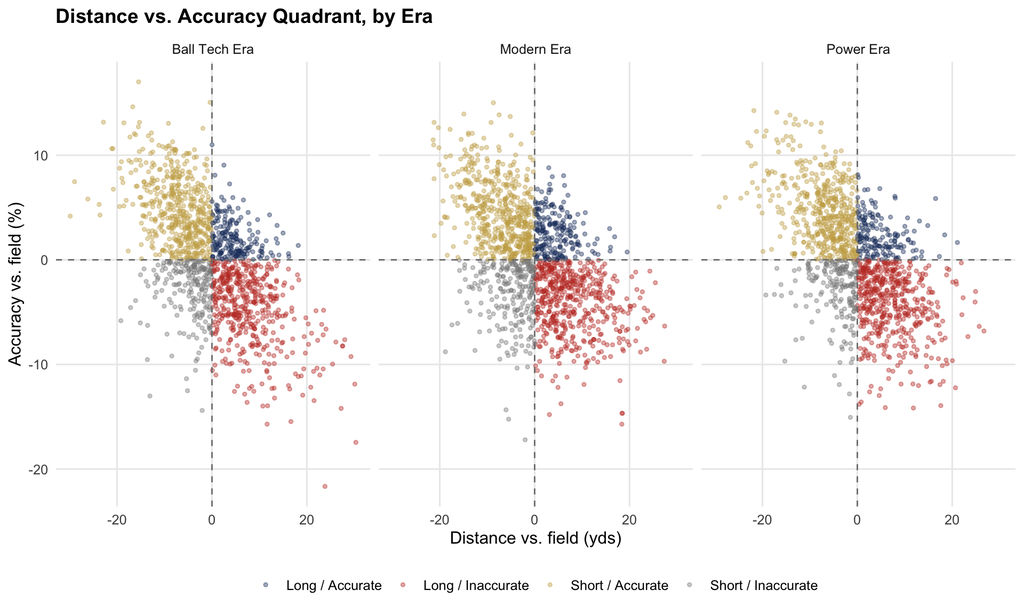

```r
p_quadrant <- df_main %>%
  filter(!is.na(era)) %>%
  ggplot(aes(dist_vs_field, acc_vs_field, color = archetype)) +
  geom_point(alpha = 0.4, size = 1) +
  geom_hline(yintercept = 0, linetype = "dashed", color = "grey50") +
  geom_vline(xintercept = 0, linetype = "dashed", color = "grey50") +
  facet_wrap(~era) +
  scale_color_manual(values = c(
    "Long / Accurate"    = COL_PRIMARY,
    "Long / Inaccurate"  = COL_ACCENT,
    "Short / Accurate"   = COL_SECONDARY,
    "Short / Inaccurate" = COL_NEUTRAL
  )) +
  labs(
    title = "Distance vs. Accuracy Quadrant, by Era",
    x = "Distance vs. field (yds)", y = "Accuracy vs. field (%)", color = NULL
  ) +
  THEME_BASE

p_quadrant
```

```r
quadrant_by_era <- df_main %>%
  filter(!is.na(era)) %>%
  count(era, archetype) %>%
  group_by(era) %>%
  mutate(pct = round(100 * n / sum(n), 1)) %>%
  ungroup()

quadrant_by_era %>% pivot_wider(id_cols = archetype, names_from = era, values_from = pct) %>% print()
```

```
## # A tibble: 4 x 4
##   archetype          `Ball Tech Era` `Modern Era` `Power Era`
##   <fct>                        <dbl>        <dbl>       <dbl>
## 1 Long / Accurate               14.5         14.3        12.5
## 2 Long / Inaccurate             34.3         34.3        36.8
## 3 Short / Accurate              36.3         35.5        36.8
## 4 Short / Inaccurate            14.9         16          13.9
```

**Finding:** the quadrant shares shift only modestly era to era — this simple heuristic is fairly stable over time. The more interesting movement shows up in sections 4-6 below, which condition on *performance* (top-25% SG_total) rather than looking at the whole field.

# 4. K-Means Clustering at 3 Eras

Same 4 variables as the docs specify (`dist_vs_field`, `acc_vs_field`, `sg_ott`, `sg_putt`), scaled, clustered separately within each of the 3 eras from section 2 — not pooled, since the point is comparing whether the *shape* of player archetypes differs by era.

```r
cluster_vars <- c("dist_vs_field", "acc_vs_field", "sg_ott", "sg_putt")
eras_present <- levels(droplevels(df_main$era))

compute_silhouette <- function(era_name, k) {
  era_data <- df_main %>% filter(era == era_name) %>% select(all_of(cluster_vars)) %>% scale()
  km <- kmeans(era_data, centers = k, nstart = 25)
  mean(silhouette(km$cluster, dist(era_data))[, 3])
}

sil_table <- expand_grid(era = eras_present, k = 2:6) %>%
  mutate(silhouette = map2_dbl(era, k, compute_silhouette)) %>%
  pivot_wider(names_from = k, values_from = silhouette, names_prefix = "k")

sil_table %>% print()
```

```
## # A tibble: 3 x 6
##   era              k2    k3    k4    k5    k6
##   <chr>         <dbl> <dbl> <dbl> <dbl> <dbl>
## 1 Ball Tech Era 0.268 0.252 0.222 0.210 0.211
## 2 Modern Era    0.255 0.242 0.230 0.228 0.232
## 3 Power Era     0.254 0.245 0.221 0.226 0.215
```

**Silhouette width favors k=2-3 in every era, declining gently rather than showing a sharp elbow.** We use k=4 anyway: the drop from k=2 to k=4 is small (not a cliff — see the table above), and k=4 gives clusters that can be compared directly against the existing 4-quadrant heuristic, which is more useful for this project’s narrative than the marginally higher silhouette width of a 2-cluster split.

```r
run_kmeans_era <- function(era_name, k = 4) {
  set.seed(2025)
  era_data_raw <- df_main %>% filter(era == era_name) %>% select(all_of(cluster_vars))
  era_scaled <- scale(era_data_raw)
  km <- kmeans(era_scaled, centers = k, nstart = 25)
  centers_unscaled <- sweep(sweep(km$centers, 2, attr(era_scaled, "scaled:scale"), `*`), 2, attr(era_scaled, "scaled:center"), `+`)
  as_tibble(centers_unscaled) %>% mutate(cluster = row_number(), era = era_name, size = km$size)
}

cluster_centers_by_era <- map_dfr(eras_present, run_kmeans_era) %>%
  mutate(era = factor(era, levels = eras_present))

cluster_centers_by_era %>% print()
```

```
## # A tibble: 12 x 7
##    dist_vs_field acc_vs_field  sg_ott  sg_putt cluster era            size
##            <dbl>        <dbl>   <dbl>    <dbl>   <int> <fct>         <int>
##  1       -8.38           5.27 -0.0661  0.161         1 Ball Tech Era   353
##  2       -0.0803         2.10  0.159  -0.339         2 Ball Tech Era   328
##  3       -2.09          -3.83 -0.340   0.254         3 Ball Tech Era   306
##  4        9.66          -3.67  0.324   0.0195        4 Ball Tech Era   375
##  5       -7.08           4.33 -0.0385  0.210         1 Modern Era      460
##  6       -0.404          1.68  0.139  -0.355         2 Modern Era      336
##  7       10.3           -2.73  0.391   0.0314        3 Modern Era      375
##  8       -1.52          -4.85 -0.372   0.166         4 Modern Era      315
##  9       -9.03           3.76 -0.158   0.261         1 Power Era       275
## 10        8.99          -2.48  0.342   0.00854       2 Power Era       396
## 11        0.643         -4.96 -0.295   0.151         3 Power Era       292
## 12       -3.48           3.84  0.109  -0.238         4 Power Era       364
```

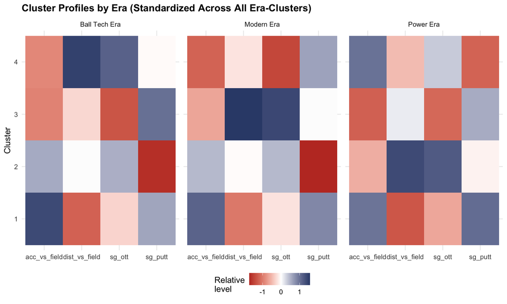

```r
p_cluster_heatmap <- cluster_centers_by_era %>%
  pivot_longer(all_of(cluster_vars), names_to = "variable", values_to = "value") %>%
  group_by(variable) %>%
  mutate(value_z = as.numeric(scale(value))) %>%
  ungroup() %>%
  ggplot(aes(variable, factor(cluster), fill = value_z)) +
  geom_tile() +
  facet_wrap(~era) +
  scale_fill_gradient2(low = COL_ACCENT, mid = "white", high = COL_PRIMARY, name = "Relative\nlevel") +
  labs(title = "Cluster Profiles by Era (Standardized Across All Era-Clusters)", x = NULL, y = "Cluster") +
  THEME_BASE

p_cluster_heatmap
```

**Finding:** the same rough 4-archetype structure (a long-and-inaccurate group, an accurate-but-short group, etc.) recurs in all 3 eras — clustering doesn’t reveal a qualitatively new player type emerging, it’s the same handful of shapes, just shifted along the distance axis as the whole field got longer (consistent with Project 1’s “uniform shift” finding).

# 5. Archetype Share Among Top-25% SG_total Performers, by Year

The whole-field quadrant shares (section 3) were fairly stable — but what about specifically among the *best* players each year? This is the section that most directly answers “are bombers more represented among top performers.”

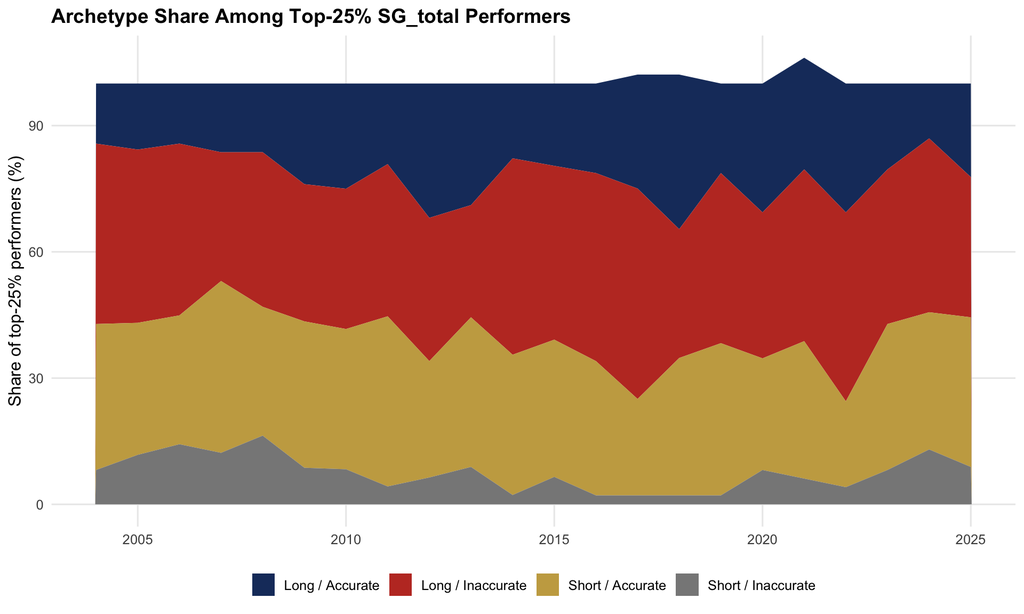

```r
top25_by_year <- df_main %>%
  group_by(year) %>%
  mutate(sg_rank_pct = percent_rank(sg_total)) %>%
  ungroup() %>%
  filter(sg_rank_pct >= 0.75)

archetype_share <- top25_by_year %>%
  count(year, archetype) %>%
  group_by(year) %>%
  mutate(pct = 100 * n / sum(n)) %>%
  ungroup()

p_archetype_share <- ggplot(archetype_share, aes(year, pct, fill = archetype)) +
  geom_area(position = "stack") +
  scale_fill_manual(values = c(
    "Long / Accurate"    = COL_PRIMARY,
    "Long / Inaccurate"  = COL_ACCENT,
    "Short / Accurate"   = COL_SECONDARY,
    "Short / Inaccurate" = COL_NEUTRAL
  )) +
  labs(
    title    = "Archetype Share Among Top-25% SG_total Performers",
    x = NULL, y = "Share of top-25% performers (%)", fill = NULL
  ) +
  THEME_BASE

p_archetype_share
```

```r
la_2004 <- archetype_share %>% filter(year == min(year), archetype == "Long / Accurate") %>% pull(pct)
la_2025 <- archetype_share %>% filter(year == max(year), archetype == "Long / Accurate") %>% pull(pct)
li_2004 <- archetype_share %>% filter(year == min(year), archetype == "Long / Inaccurate") %>% pull(pct)
li_2025 <- archetype_share %>% filter(year == max(year), archetype == "Long / Inaccurate") %>% pull(pct)
```

**Finding:** “Long/Accurate” share rose from 14.3% (2004) to 22.2% (2025), while “Long/Inaccurate” — the pure “bomber” archetype — *fell* from 42.9% to 33.3%. The popular “bombers are taking over” framing undersells what’s actually happening: the most successful profile now combines distance *with* accuracy, rather than trading one for the other.

# 6. Era Comparison: MANOVA + Radar Chart

Same top-25%-SG_total population, contrasting Early (2004-2010) vs. Late (2018-2025) — skipping the middle “Modern Era” for a clean two-group test, using the outer two of the 3 eras from section 4.

```r
early <- top25_by_year %>% filter(year >= 2004, year <= 2010) %>% mutate(era_grp = "Early (2004-2010)")
late  <- top25_by_year %>% filter(year >= 2018, year <= 2025) %>% mutate(era_grp = "Late (2018-2025)")
combined <- bind_rows(early, late)

cat("n early:", nrow(early), " n late:", nrow(late), "\n")
```

```
## n early: 341  n late: 383
```

```r
Y <- as.matrix(combined %>% select(all_of(cluster_vars)))
fit_manova <- manova(Y ~ era_grp, data = combined)
summary(fit_manova, test = "Pillai")
```

```
##            Df  Pillai approx F num Df den Df   Pr(>F)
## era_grp     1 0.06684   12.875      4    719 3.96e-10 ***
## Residuals 722
## ---
## Signif. codes:  0 '***' 0.001 '**' 0.01 '*' 0.05 '.' 0.1 ' ' 1
```

```r
profile_by_era <- combined %>%
  group_by(era_grp) %>%
  summarise(across(all_of(cluster_vars), mean), .groups = "drop")

profile_by_era %>% print()
```

```
## # A tibble: 2 x 5
##   era_grp           dist_vs_field acc_vs_field sg_ott sg_putt
##   <chr>                     <dbl>        <dbl>  <dbl>   <dbl>
## 1 Early (2004-2010)          1.11        0.455  0.236   0.197
## 2 Late (2018-2025)           2.97        0.859  0.270   0.206
```

**Finding:** the MANOVA is highly significant (Pillai’s trace, p < 0.001) — the multivariate profile of top performers has genuinely shifted, not just distance in isolation. `dist_vs_field` roughly tripled (1.11 → 2.97) **and** `acc_vs_field` also grew (0.45 → 0.86) — top performers pulled further ahead of the field on *both* axes, not by trading one for the other. This nuances Project 1’s field-wide finding (the distance-accuracy trade-off has strengthened *overall*): true for the field generally, but the very best players increasingly buck that trade-off.

## 6.1 Radar chart

Each variable standardized across the pooled early+late population first (not just the two era-means — standardizing only two aggregate points would force every variable to an identical, meaningless spread), then averaged within era.

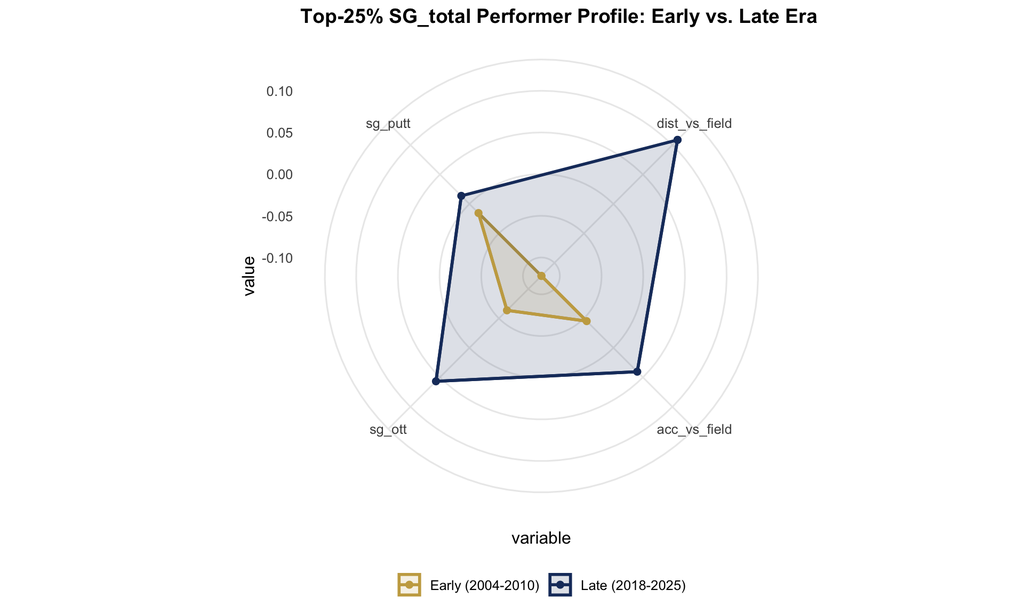

```r
combined_z <- combined %>%
  mutate(across(all_of(cluster_vars), ~as.numeric(scale(.x)), .names = "z_{.col}"))

radar_data <- combined_z %>%
  group_by(era_grp) %>%
  summarise(across(starts_with("z_"), mean), .groups = "drop") %>%
  pivot_longer(-era_grp, names_to = "variable", values_to = "value") %>%
  mutate(variable = str_remove(variable, "^z_"))

radar_closed <- radar_data %>%
  group_by(era_grp) %>%
  group_modify(~bind_rows(.x, .x[1, ])) %>%
  ungroup() %>%
  mutate(variable = factor(variable, levels = unique(variable)))

p_radar <- ggplot(radar_closed, aes(x = variable, y = value, group = era_grp, color = era_grp)) +
  geom_polygon(aes(fill = era_grp), alpha = 0.15, linewidth = 1) +
  geom_line(linewidth = 1) +
  geom_point(size = 2) +
  scale_color_manual(values = c("Early (2004-2010)" = COL_SECONDARY, "Late (2018-2025)" = COL_PRIMARY)) +
  scale_fill_manual(values = c("Early (2004-2010)" = COL_SECONDARY, "Late (2018-2025)" = COL_PRIMARY)) +
  coord_radar() +
  labs(title = "Top-25% SG_total Performer Profile: Early vs. Late Era", color = NULL, fill = NULL) +
  THEME_BASE

p_radar
```

**Finding:** the “Late” polygon fully encloses “Early” on all 4 axes — a direct visual confirmation of the MANOVA result, not just a statistical abstraction.

# 7. SG-Category Clustering (Added Analysis)

Beyond distance/accuracy, what does clustering purely on the 4 Strokes Gained categories reveal about game-*style* archetypes, and how much does off-the-tee specifically drive them? Each component is standardized **within year first** (not raw) — Project 3 already found SG_OTT’s importance has been rising over time, and we don’t want that secular drift conflated with player-style differences here.

```r
df_sg <- df_main %>%
  group_by(year) %>%
  mutate(across(c(sg_ott, sg_apr, sg_arg, sg_putt), ~as.numeric(scale(.x)), .names = "z_{.col}")) %>%
  ungroup()

sg_cluster_vars <- c("z_sg_ott", "z_sg_apr", "z_sg_arg", "z_sg_putt")
X_sg <- df_sg %>% select(all_of(sg_cluster_vars)) %>% as.matrix()

sil_sg <- map_dbl(2:6, function(k) {
  set.seed(2025)
  km <- kmeans(X_sg, centers = k, nstart = 25)
  mean(silhouette(km$cluster, dist(X_sg))[, 3])
})

cat("Silhouette scores k=2..6 (SG-component clustering, full 2004-2025):\n")
```

```
## Silhouette scores k=2..6 (SG-component clustering, full 2004-2025):
```

```r
print(setNames(round(sil_sg, 3), 2:6))
```

```
##     2     3     4     5     6
## 0.218 0.189 0.175 0.173 0.170
```

Same tradeoff as section 4 — silhouette gently prefers fewer clusters, k=4 used again for interpretability and consistency with the rest of the notebook.

```r
set.seed(2025)
km_sg <- kmeans(X_sg, centers = 4, nstart = 25)
df_sg$sg_cluster <- factor(km_sg$cluster)

centers_sg <- as_tibble(km_sg$centers) %>%
  mutate(cluster = row_number(), size = km_sg$size) %>%
  mutate(label = case_when(
    z_sg_ott > 0 & z_sg_apr > 0 & z_sg_arg > 0 & z_sg_putt > 0 ~ "All-around positive",
    z_sg_putt < -0.5 & z_sg_ott > 0 & z_sg_apr > 0             ~ "Ball-striker, weak putter",
    z_sg_ott < -0.5 & z_sg_apr < -0.5                          ~ "Weak long game",
    TRUE                                                       ~ paste("Cluster", cluster)
  ))

centers_sg %>% print()
```

```
## # A tibble: 4 x 7
##   z_sg_ott z_sg_apr z_sg_arg z_sg_putt cluster  size label
##      <dbl>    <dbl>    <dbl>     <dbl>   <int> <int> <chr>
## 1    0.265   -0.464  -1.08      -0.195       1  1034 Cluster 1
## 2   -1.05    -0.802   0.493      0.447       2  1053 Weak long game
## 3    0.248    0.607   0.585      0.690       3  1088 All-around positive
## 4    0.557    0.664  -0.0350    -1.02        4  1000 Ball-striker, weak putter
```

```r
ranges <- centers_sg %>%
  summarise(across(all_of(sg_cluster_vars), ~max(.x) - min(.x))) %>%
  pivot_longer(everything(), names_to = "component", values_to = "range") %>%
  arrange(range)

ranges %>% print()
```

```
## # A tibble: 4 x 2
##   component range
##   <chr>     <dbl>
## 1 z_sg_apr   1.47
## 2 z_sg_ott   1.60
## 3 z_sg_arg   1.67
## 4 z_sg_putt  1.71
```

## 7.1 Cluster Share Among Top Performers, by Year

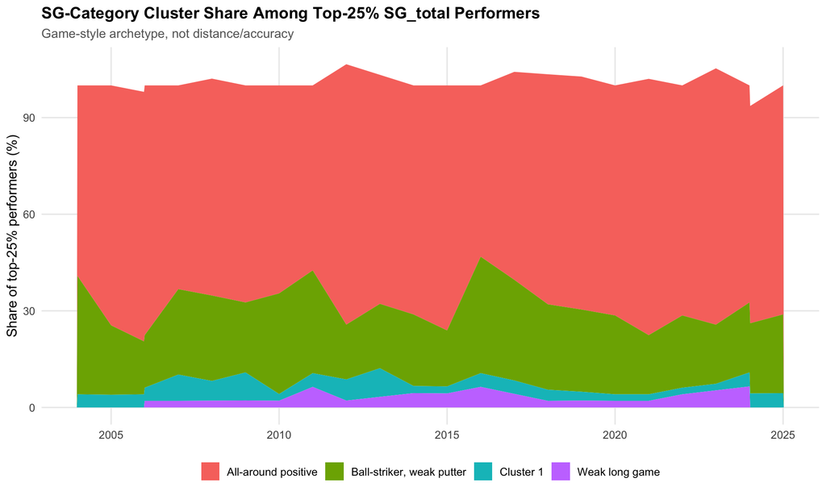

```r
df_sg <- df_sg %>% group_by(year) %>% mutate(sg_rank_pct = percent_rank(sg_total)) %>% ungroup()
top25_sg <- df_sg %>%
  filter(sg_rank_pct >= 0.75) %>%
  left_join(centers_sg %>% select(cluster, label) %>% mutate(cluster = factor(cluster)), by = c("sg_cluster" = "cluster"))

sg_share <- top25_sg %>%
  count(year, label) %>%
  group_by(year) %>%
  mutate(pct = 100 * n / sum(n)) %>%
  ungroup()

p_sg_share <- ggplot(sg_share, aes(year, pct, fill = label)) +
  geom_area(position = "stack") +
  labs(
    title    = "SG-Category Cluster Share Among Top-25% SG_total Performers",
    subtitle = "Game-style archetype, not distance/accuracy",
    x = NULL, y = "Share of top-25% performers (%)", fill = NULL
  ) +
  THEME_BASE

p_sg_share
```

```r
allaround_label <- centers_sg$label[centers_sg$label == "All-around positive"][1]
ballstriker_label <- centers_sg$label[centers_sg$label == "Ball-striker, weak putter"][1]

allaround_2004 <- sg_share %>% filter(year == min(year), label == allaround_label) %>% pull(pct)
allaround_2025 <- sg_share %>% filter(year == max(year), label == allaround_label) %>% pull(pct)
ballstriker_2004 <- sg_share %>% filter(year == min(year), label == ballstriker_label) %>% pull(pct)
ballstriker_2025 <- sg_share %>% filter(year == max(year), label == ballstriker_label) %>% pull(pct)
```

# 8. Summary